# Importing and Cleaning Data in R: Case Studies

William Surles

2017-07-13

# Introduction

Course notes for [Importing and Cleaning Data in R: Case Studies](https://www.datacamp.com/courses/importing-cleaning-data-in-r-case-studies)

## Whats Covered

- Ticket Sales Data
- MBTA Ridership Data
- World Food Facts
- School Attendance Data

# Ticket Sales Data

## Importing the data

```r
# Import sales.csv: sales
url_sales <- 'http://s3.amazonaws.com/assets.datacamp.com/production/course_1294/datasets/sales.csv'
sales <- read.csv(url_sales, stringsAsFactors=F)
```

## Examining the data

```r
# View dimensions of sales
dim(sales)
```

```
## [1] 5000   46
```

```r
# Inspect first 6 rows of sales
head(sales)
```

```
##   X             event_id       primary_act_id     secondary_act_id
## 1 1 abcaf1adb99a935fc661 43f0436b905bfa7c2eec b85143bf51323b72e53c
## 2 2 6c56d7f08c95f2aa453c 1a3e9aecd0617706a794 f53529c5679ea6ca5a48
## 3 3 c7ab4524a121f9d687d2 4b677c3f5bec71eec8d1 b85143bf51323b72e53c
## 4 4 394cb493f893be9b9ed1 b1ccea01ad6ef8522796 b85143bf51323b72e53c
## 5 5 55b5f67e618557929f48 91c03a34b562436efa3c b85143bf51323b72e53c
## 6 6 4f10fd8b9f550352bd56 ac4b847b3fde66f2117e 63814f3d63317f1b56c4
##    purch_party_lkup_id
## 1 7dfa56dd7d5956b17587
## 2 4f9e6fc637eaf7b736c2
## 3 6c2545703bd527a7144d
## 4 527d6b1eaffc69ddd882
## 5 8bd62c394a35213bdf52
## 6 3b3a628f83135acd0676
##                                                       event_name
```

[output cut: 97 more lines]

```r
# View column names of sales
names(sales)
```

```
##  [1] "X"                      "event_id"
##  [3] "primary_act_id"         "secondary_act_id"
##  [5] "purch_party_lkup_id"    "event_name"
##  [7] "primary_act_name"       "secondary_act_name"
##  [9] "major_cat_name"         "minor_cat_name"
## [11] "la_event_type_cat"      "event_disp_name"
## [13] "ticket_text"            "tickets_purchased_qty"
## [15] "trans_face_val_amt"     "delivery_type_cd"
## [17] "event_date_time"        "event_dt"
## [19] "presale_dt"             "onsale_dt"
## [21] "sales_ord_create_dttm"  "sales_ord_tran_dt"
## [23] "print_dt"               "timezn_nm"
## [25] "venue_city"             "venue_state"
## [27] "venue_postal_cd_sgmt_1" "sales_platform_cd"
## [29] "print_flg"              "la_valid_tkt_event_flg"
## [31] "fin_mkt_nm"             "web_session_cookie_val"
## [33] "gndr_cd"                "age_yr"
## [35] "income_amt"             "edu_val"
## [37] "edu_1st_indv_val"       "edu_2nd_indv_val"
## [39] "adults_in_hh_num"       "married_ind"
## [41] "child_present_ind"      "home_owner_ind"
## [43] "occpn_val"              "occpn_1st_val"
## [45] "occpn_2nd_val"          "dist_to_ven"
```

## Summarizing the data

```r
# Look at structure of sales
str(sales)
```

```
## 'data.frame':    5000 obs. of  46 variables:
##  $ X                     : int  1 2 3 4 5 6 7 8 9 10 ...
##  $ event_id              : chr  "abcaf1adb99a935fc661" "6c56d7f08c95f2aa453c" "c7ab4524a121f9d687d2" "394cb493f893be9b9ed1" ...
##  $ primary_act_id        : chr  "43f0436b905bfa7c2eec" "1a3e9aecd0617706a794" "4b677c3f5bec71eec8d1" "b1ccea01ad6ef8522796" ...
##  $ secondary_act_id      : chr  "b85143bf51323b72e53c" "f53529c5679ea6ca5a48" "b85143bf51323b72e53c" "b85143bf51323b72e53c" ...
##  $ purch_party_lkup_id   : chr  "7dfa56dd7d5956b17587" "4f9e6fc637eaf7b736c2" "6c2545703bd527a7144d" "527d6b1eaffc69ddd882" ...
##  $ event_name            : chr  "Xfinity Center Mansfield Premier Parking: Florida Georgia Line" "Gorge Camping - dave matthews band - sept 3-7" "Dodge Theatre Adams Street Parking - benise" "Gexa Energy Pavilion Vip Parking : kid rock with sheryl crow" ...
##  $ primary_act_name      : chr  "XFINITY Center Mansfield Premier Parking" "Gorge Camping" "Parking Event" "Gexa Energy Pavilion VIP Parking" ...
##  $ secondary_act_name    : chr  "NULL" "Dave Matthews Band" "NULL" "NULL" ...
##  $ major_cat_name        : chr  "MISC" "MISC" "MISC" "MISC" ...
##  $ minor_cat_name        : chr  "PARKING" "CAMPING" "PARKING" "PARKING" ...
##  $ la_event_type_cat     : chr  "PARKING" "INVALID" "PARKING" "PARKING" ...
##  $ event_disp_name       : chr  "Xfinity Center Mansfield Premier Parking: Florida Georgia Line" "Gorge Camping - dave matthews band - sept 3-7" "Dodge Theatre Adams Street Parking - benise" "Gexa Energy Pavilion Vip Parking : kid rock with sheryl crow" ...
##  $ ticket_text           : chr  "   THIS TICKET IS VALID        FOR PARKING ONLY         GOOD THIS DAY ONLY       PREMIER PARKING PASS    XFINIT"| __truncated__ "%OVERNIGHT C A M P I N G%* * * * * *%GORGE CAMPGROUND%* GOOD THIS DATE ONLY *%SEP 3 - 6, 2009" "ADAMS STREET GARAGE%PARKING FOR 4/21/06…
##  $ tickets_purchased_qty : int  1 1 1 1 1 2 1 1 1 1 ...
```

[output cut: 32 more lines]

```r
# View a summary of sales
summary(sales)
```

```
##        X          event_id         primary_act_id     secondary_act_id
##  Min.   :   1   Length:5000        Length:5000        Length:5000
##  1st Qu.:1251   Class :character   Class :character   Class :character
##  Median :2500   Mode  :character   Mode  :character   Mode  :character
##  Mean   :2500
##  3rd Qu.:3750
##  Max.   :5000
##
##  purch_party_lkup_id  event_name        primary_act_name
##  Length:5000         Length:5000        Length:5000
##  Class :character    Class :character   Class :character
##  Mode  :character    Mode  :character   Mode  :character
##
##
##
##
##  secondary_act_name major_cat_name     minor_cat_name
##  Length:5000        Length:5000        Length:5000
##  Class :character   Class :character   Class :character
##  Mode  :character   Mode  :character   Mode  :character
##
##
##
##
##  la_event_type_cat  event_disp_name    ticket_text
##  Length:5000        Length:5000        Length:5000
##  Class :character   Class :character   Class :character
##  Mode  :character   Mode  :character   Mode  :character
##
##
##
##
##  tickets_purchased_qty trans_face_val_amt delivery_type_cd
##  Min.   :1.000         Min.   :   1.00    Length:5000
##  1st Qu.:1.000         1st Qu.:  20.00    Class :character
##  Median :1.000         Median :  30.00    Mode  :character
##  Mean   :1.639         Mean   :  77.08
##  3rd Qu.:2.000         3rd Qu.:  85.00
##  Max.   :8.000         Max.   :1520.88
##
```

[output cut: 65 more lines]

```
##  Length:5000        Length:5000        Length:5000
##  Class :character   Class :character   Class :character
##  Mode  :character   Mode  :character   Mode  :character
##
##
##
##
##  occpn_1st_val      occpn_2nd_val       dist_to_ven
##  Length:5000        Length:5000        Min.   :   0.0
##  Class :character   Class :character   1st Qu.:  12.0
##  Mode  :character   Mode  :character   Median :  26.0
##                                        Mean   : 158.2
##                                        3rd Qu.:  77.5
##                                        Max.   :2548.0
##                                        NA's   :4677
```

```r
# Load dplyr
library(dplyr)

# Get a glimpse of sales
glimpse(sales)
```

```
## Observations: 5,000
## Variables: 46
## $ X                      <int> 1, 2, 3, 4, 5, 6, 7, 8, 9, 10, 11, 12, ...
## $ event_id               <chr> "abcaf1adb99a935fc661", "6c56d7f08c95f2...
## $ primary_act_id         <chr> "43f0436b905bfa7c2eec", "1a3e9aecd06177...
## $ secondary_act_id       <chr> "b85143bf51323b72e53c", "f53529c5679ea6...
## $ purch_party_lkup_id    <chr> "7dfa56dd7d5956b17587", "4f9e6fc637eaf7...
## $ event_name             <chr> "Xfinity Center Mansfield Premier Parki...
## $ primary_act_name       <chr> "XFINITY Center Mansfield Premier Parki...
## $ secondary_act_name     <chr> "NULL", "Dave Matthews Band", "NULL", "...
## $ major_cat_name         <chr> "MISC", "MISC", "MISC", "MISC", "MISC",...
## $ minor_cat_name         <chr> "PARKING", "CAMPING", "PARKING", "PARKI...
## $ la_event_type_cat      <chr> "PARKING", "INVALID", "PARKING", "PARKI...
## $ event_disp_name        <chr> "Xfinity Center Mansfield Premier Parki...
## $ ticket_text            <chr> "   THIS TICKET IS VALID        FOR PAR...
```

[output cut: 33 more lines]

## Removing redundant info

```r
# Remove the first column of sales: sales2
sales2 <- sales[,-1]
str(sales[,1:5])
```

```
## 'data.frame':    5000 obs. of  5 variables:
##  $ X                  : int  1 2 3 4 5 6 7 8 9 10 ...
##  $ event_id           : chr  "abcaf1adb99a935fc661" "6c56d7f08c95f2aa453c" "c7ab4524a121f9d687d2" "394cb493f893be9b9ed1" ...
##  $ primary_act_id     : chr  "43f0436b905bfa7c2eec" "1a3e9aecd0617706a794" "4b677c3f5bec71eec8d1" "b1ccea01ad6ef8522796" ...
##  $ secondary_act_id   : chr  "b85143bf51323b72e53c" "f53529c5679ea6ca5a48" "b85143bf51323b72e53c" "b85143bf51323b72e53c" ...
##  $ purch_party_lkup_id: chr  "7dfa56dd7d5956b17587" "4f9e6fc637eaf7b736c2" "6c2545703bd527a7144d" "527d6b1eaffc69ddd882" ...
```

```r
str(sales2[,1:5])
```

```
## 'data.frame':    5000 obs. of  5 variables:
##  $ event_id           : chr  "abcaf1adb99a935fc661" "6c56d7f08c95f2aa453c" "c7ab4524a121f9d687d2" "394cb493f893be9b9ed1" ...
##  $ primary_act_id     : chr  "43f0436b905bfa7c2eec" "1a3e9aecd0617706a794" "4b677c3f5bec71eec8d1" "b1ccea01ad6ef8522796" ...
##  $ secondary_act_id   : chr  "b85143bf51323b72e53c" "f53529c5679ea6ca5a48" "b85143bf51323b72e53c" "b85143bf51323b72e53c" ...
##  $ purch_party_lkup_id: chr  "7dfa56dd7d5956b17587" "4f9e6fc637eaf7b736c2" "6c2545703bd527a7144d" "527d6b1eaffc69ddd882" ...
##  $ event_name         : chr  "Xfinity Center Mansfield Premier Parking: Florida Georgia Line" "Gorge Camping - dave matthews band - sept 3-7" "Dodge Theatre Adams Street Parking - benise" "Gexa Energy Pavilion Vip Parking : kid rock with sheryl crow" ...
```

## Information not worth keeping

```r
# Define a vector of column indices: keep
## We don't want the first 4 coumns or the last 15
keep <- seq(5,ncol(sales2)-15,1)

# Subset sales2 using keep: sales3
sales3 <- sales2[,keep]
glimpse(sales3)
```

```
## Observations: 5,000
## Variables: 26
## $ event_name             <chr> "Xfinity Center Mansfield Premier Parki...
## $ primary_act_name       <chr> "XFINITY Center Mansfield Premier Parki...
## $ secondary_act_name     <chr> "NULL", "Dave Matthews Band", "NULL", "...
## $ major_cat_name         <chr> "MISC", "MISC", "MISC", "MISC", "MISC",...
## $ minor_cat_name         <chr> "PARKING", "CAMPING", "PARKING", "PARKI...
## $ la_event_type_cat      <chr> "PARKING", "INVALID", "PARKING", "PARKI...
## $ event_disp_name        <chr> "Xfinity Center Mansfield Premier Parki...
## $ ticket_text            <chr> "   THIS TICKET IS VALID        FOR PAR...
## $ tickets_purchased_qty  <int> 1, 1, 1, 1, 1, 2, 1, 1, 1, 1, 1, 2, 4, ...
## $ trans_face_val_amt     <dbl> 45, 75, 5, 20, 20, 10, 30, 28, 20, 25, ...
## $ delivery_type_cd       <chr> "eTicket", "TicketFast", "TicketFast", ...
## $ event_date_time        <chr> "2015-09-12 23:30:00", "2009-09-05 01:0...
## $ event_dt               <chr> "2015-09-12", "2009-09-04", "2006-04-21...
## $ presale_dt             <chr> "NULL", "NULL", "NULL", "NULL", "2005-0...
## $ onsale_dt              <chr> "2015-05-15", "2009-03-13", "2006-02-25...
## $ sales_ord_create_dttm  <chr> "2015-09-11 18:17:45", "2009-07-06 00:0...
## $ sales_ord_tran_dt      <chr> "2015-09-11", "2009-07-05", "2006-04-05...
## $ print_dt               <chr> "2015-09-12", "2009-09-01", "2006-04-05...
## $ timezn_nm              <chr> "EST", "PST", "MST", "CST", "PST", "PST...
## $ venue_city             <chr> "MANSFIELD", "QUINCY", "PHOENIX", "DALL...
## $ venue_state            <chr> "MASSACHUSETTS", "WASHINGTON", "ARIZONA...
## $ venue_postal_cd_sgmt_1 <chr> "02048", "98848", "85003", "75210", "98...
## $ sales_platform_cd      <chr> "www.concerts.livenation.com", "NULL", ...
## $ print_flg              <chr> "T ", "T ", "T ", "T ", "T ", "T ", "T ...
## $ la_valid_tkt_event_flg <chr> "N ", "N ", "N ", "N ", "N ", "N ", "N ...
## $ fin_mkt_nm             <chr> "Boston", "Seattle", "Arizona", "Dallas...
```

## Separating columns

```r
# Load tidyr
library(tidyr)

# Split event_date_time: sales4
head(sales3$event_date_time)
```

```
## [1] "2015-09-12 23:30:00" "2009-09-05 01:00:00" "2006-04-22 01:30:00"
## [4] "2011-09-03 00:00:00" "2005-07-31 01:00:00" "2012-07-22 02:00:00"
```

```r
sales4 <- separate(sales3, event_date_time, c('event_dt', 'event_time'), sep = " ")

## check new columns
col <- str_detect(names(sales4),'event')
glimpse(sales4[,col])
```

```
## Observations: 5,000
## Variables: 7
## $ event_name             <chr> "Xfinity Center Mansfield Premier Parki...
## $ la_event_type_cat      <chr> "PARKING", "INVALID", "PARKING", "PARKI...
## $ event_disp_name        <chr> "Xfinity Center Mansfield Premier Parki...
## $ event_dt               <chr> "2015-09-12", "2009-09-05", "2006-04-22...
## $ event_time             <chr> "23:30:00", "01:00:00", "01:30:00", "00...
## $ event_dt.1             <chr> "2015-09-12", "2009-09-04", "2006-04-21...
## $ la_valid_tkt_event_flg <chr> "N ", "N ", "N ", "N ", "N ", "N ", "N ...
```

```r
# Split sales_ord_create_dttm: sales5
head(sales4$sales_ord_create_dttm)
```

```
## [1] "2015-09-11 18:17:45" "2009-07-06 00:00:00" "2006-04-05 00:00:00"
## [4] "2011-07-01 17:38:50" "2005-06-18 00:00:00" "2012-07-21 17:20:18"
```

```r
sales5 <- separate(sales4, sales_ord_create_dttm, c('ord_create_dt', 'ord_create_time'), sep = " ")

## check new columns
col <- str_detect(names(sales5),'ord_create')
glimpse(sales5[,col])
```

```
## Observations: 5,000
## Variables: 2
## $ ord_create_dt   <chr> "2015-09-11", "2009-07-06", "2006-04-05", "201...
## $ ord_create_time <chr> "18:17:45", "00:00:00", "00:00:00", "17:38:50"...
```

## Dealing with warnings

- When running the `separate` in the last code block the following warning is printed to the console
  - `Warning message: Too few values at 4 locations: 2516, 3863, 4082, 4183`
  - This does not show in the html doc becasue I have `warnings=F` set on all code chunks
  - I do this so warnings don’t make the final doc messy, but its still a good idea to check on them as they do in the next couple exercises

```r
# Define an issues vector
issues <- c(2516, 3863, 4082, 4183)

# Print values of sales_ord_create_dttm at these indices
sales3$sales_ord_create_dttm[issues]
```

```
## [1] "NULL" "NULL" "NULL" "NULL"
```

```r
# Print a well-behaved value of sales_ord_create_dttm
sales3$sales_ord_create_dttm[2517]
```

```
## [1] "2013-08-04 23:07:19"
```

- This just shows that the values in these rows indicated in the warning are NULL.
- So, it makes sense that there would be a warnging, but there is nothing we can do about it.

## Identifying dates

```r
# Load stringr
library(stringr)

# Find columns of sales5 containing "dt": date_cols
date_cols <- str_detect(colnames(sales5), "dt")
glimpse(sales5[,date_cols])
```

```
## Observations: 5,000
## Variables: 7
## $ event_dt          <chr> "2015-09-12", "2009-09-05", "2006-04-22", "2...
## $ event_dt.1        <chr> "2015-09-12", "2009-09-04", "2006-04-21", "2...
## $ presale_dt        <chr> "NULL", "NULL", "NULL", "NULL", "2005-03-02"...
## $ onsale_dt         <chr> "2015-05-15", "2009-03-13", "2006-02-25", "2...
## $ ord_create_dt     <chr> "2015-09-11", "2009-07-06", "2006-04-05", "2...
## $ sales_ord_tran_dt <chr> "2015-09-11", "2009-07-05", "2006-04-05", "2...
## $ print_dt          <chr> "2015-09-12", "2009-09-01", "2006-04-05", "2...
```

```r
# Load lubridate
library(lubridate)

# Coerce date columns into Date objects
sales5[, date_cols] <- lapply(sales5[, date_cols], ymd)

# Check column types
glimpse(sales5[,date_cols])
```

```
## Observations: 5,000
## Variables: 7
## $ event_dt          <date> 2015-09-12, 2009-09-05, 2006-04-22, 2011-09...
## $ event_dt.1        <date> 2015-09-12, 2009-09-04, 2006-04-21, 2011-09...
## $ presale_dt        <date> NA, NA, NA, NA, 2005-03-02, NA, NA, NA, NA,...
## $ onsale_dt         <date> 2015-05-15, 2009-03-13, 2006-02-25, 2011-04...
## $ ord_create_dt     <date> 2015-09-11, 2009-07-06, 2006-04-05, 2011-07...
## $ sales_ord_tran_dt <date> 2015-09-11, 2009-07-05, 2006-04-05, 2011-07...
## $ print_dt          <date> 2015-09-12, 2009-09-01, 2006-04-05, 2011-07...
```

## More warnings!

- Aight, so when running the `ymd` function in the lapply above I get the following warnings in the console
  - `Warning message: 2892 failed to parse.`
  - `Warning message: 101 failed to parse.`
  - `Warning message: 4 failed to parse.`
  - `Warning message: 424 failed to parse.`
- These warnings are saying there were values that could not be converted to a date.
  - We can check to see if these just match up to the number of values that are `NA`
  - We `lapply` the `ia.na` function on all date columns
  - Then count the number of `TRUE`s
  - And we see that the counts match the warnings exactly.

```r
## stringr is loaded

# Find date columns (don't change)
date_cols <- str_detect(names(sales5), "dt")

# Create logical vectors indicating missing values (don't change)
missing <- lapply(sales5[, date_cols], is.na)

# Create a numerical vector that counts missing values: num_missing
num_missing <- sapply(missing, sum)

# Print num_missing
num_missing
```

```
##          event_dt        event_dt.1        presale_dt         onsale_dt
##                 0                 0              2892               101
##     ord_create_dt sales_ord_tran_dt          print_dt
##                 4                 0               424
```

## Combining columns

```r
## tidyr is loaded

# Combine the venue_city and venue_state columns
sales6 <- unite(sales5, venue_city_state, venue_city, venue_state, sep = ", ")

# View the head of sales6
head(sales6)
```

```
##                                                       event_name
## 1 Xfinity Center Mansfield Premier Parking: Florida Georgia Line
## 2                  Gorge Camping - dave matthews band - sept 3-7
## 3                    Dodge Theatre Adams Street Parking - benise
## 4   Gexa Energy Pavilion Vip Parking : kid rock with sheryl crow
## 5                                  Premier Parking - motley crue
## 6                                      Fast Lane Access: Journey
##                           primary_act_name secondary_act_name
## 1 XFINITY Center Mansfield Premier Parking               NULL
## 2                            Gorge Camping Dave Matthews Band
## 3                            Parking Event               NULL
## 4         Gexa Energy Pavilion VIP Parking               NULL
## 5 White River Amphitheatre Premier Parking               NULL
## 6                         Fast Lane Access            Journey
##   major_cat_name         minor_cat_name la_event_type_cat
```

[output cut: 55 more lines]

```r
head(sales6$venue_city_state)
```

```
## [1] "MANSFIELD, MASSACHUSETTS"   "QUINCY, WASHINGTON"
## [3] "PHOENIX, ARIZONA"           "DALLAS, TEXAS"
## [5] "AUBURN, WASHINGTON"         "SAN BERNARDINO, CALIFORNIA"
```

# MBTA Ridership Data

## Using readxl

- I need to pull this dataset down from aws then load

```r
# Load readxl
library(readxl)

# Import mbta.xlsx and skip first row: mbta
url_mbta <- 'http://s3.amazonaws.com/assets.datacamp.com/production/course_1294/datasets/mbta.xlsx'
download.file(url_mbta, 'data/mbta.xlsx')
mbta <- read_excel('data/mbta.xlsx', skip=1)
```

## Examining the data

```r
# View the structure of mbta
str(mbta)
```

```
## Classes 'tbl_df', 'tbl' and 'data.frame':    11 obs. of  60 variables:
##  $ X__1   : num  1 2 3 4 5 6 7 8 9 10 ...
##  $ mode   : chr  "All Modes by Qtr" "Boat" "Bus" "Commuter Rail" ...
##  $ 2007-01: chr  "NA" "4" "335.819" "142.2" ...
##  $ 2007-02: chr  "NA" "3.6" "338.675" "138.5" ...
##  $ 2007-03: num  1188 40 340 138 459 ...
##  $ 2007-04: chr  "NA" "4.3" "352.162" "139.5" ...
##  $ 2007-05: chr  "NA" "4.9" "354.367" "139" ...
##  $ 2007-06: num  1246 5.8 350.5 143 477 ...
##  $ 2007-07: chr  "NA" "6.521" "357.519" "142.391" ...
##  $ 2007-08: chr  "NA" "6.572" "355.479" "142.364" ...
##  $ 2007-09: num  1256.57 5.47 372.6 143.05 499.57 ...
##  $ 2007-10: chr  "NA" "5.145" "368.847" "146.542" ...
##  $ 2007-11: chr  "NA" "3.763" "330.826" "145.089" ...
##  $ 2007-12: num  1216.89 2.98 312.92 141.59 448.27 ...
```

[output cut: 46 more lines]

```r
# View the first 6 rows of mbta
head(mbta)
```

```
## # A tibble: 6 x 60
##    X__1             mode `2007-01` `2007-02` `2007-03` `2007-04` `2007-05`
##   <dbl>            <chr>     <chr>     <chr>     <dbl>     <chr>     <chr>
## 1     1 All Modes by Qtr        NA        NA  1187.653        NA        NA
## 2     2             Boat         4       3.6    40.000       4.3       4.9
## 3     3              Bus   335.819   338.675   339.867   352.162   354.367
## 4     4    Commuter Rail     142.2     138.5   137.700     139.5       139
## 5     5       Heavy Rail   435.294   448.271   458.583   472.201   474.579
## 6     6       Light Rail   227.231   240.262   241.444   255.557   248.262
## # ... with 53 more variables: `2007-06` <dbl>, `2007-07` <chr>,
## #   `2007-08` <chr>, `2007-09` <dbl>, `2007-10` <chr>, `2007-11` <chr>,
## #   `2007-12` <dbl>, `2008-01` <chr>, `2008-02` <chr>, `2008-03` <dbl>,
## #   `2008-04` <chr>, `2008-05` <chr>, `2008-06` <dbl>, `2008-07` <chr>,
## #   `2008-08` <chr>, `2008-09` <dbl>, `2008-10` <chr>, `2008-11` <chr>,
## #   `2008-12` <dbl>, `2009-01` <chr>, `2009-02` <chr>, `2009-03` <dbl>,
## #   `2009-04` <chr>, `2009-05` <chr>, `2009-06` <dbl>, `2009-07` <chr>,
## #   `2009-08` <chr>, `2009-09` <dbl>, `2009-10` <chr>, `2009-11` <chr>,
## #   `2009-12` <dbl>, `2010-01` <chr>, `2010-02` <chr>, `2010-03` <dbl>,
## #   `2010-04` <chr>, `2010-05` <chr>, `2010-06` <dbl>, `2010-07` <chr>,
## #   `2010-08` <chr>, `2010-09` <dbl>, `2010-10` <chr>, `2010-11` <chr>,
## #   `2010-12` <dbl>, `2011-01` <chr>, `2011-02` <chr>, `2011-03` <dbl>,
## #   `2011-04` <chr>, `2011-05` <chr>, `2011-06` <dbl>, `2011-07` <chr>,
## #   `2011-08` <chr>, `2011-09` <dbl>, `2011-10` <chr>
```

```r
# View a summary of mbta
summary(mbta)
```

```
##       X__1          mode             2007-01            2007-02
##  Min.   : 1.0   Length:11          Length:11          Length:11
##  1st Qu.: 3.5   Class :character   Class :character   Class :character
##  Median : 6.0   Mode  :character   Mode  :character   Mode  :character
##  Mean   : 6.0
##  3rd Qu.: 8.5
##  Max.   :11.0
##     2007-03           2007-04            2007-05
##  Min.   :   0.114   Length:11          Length:11
##  1st Qu.:   9.278   Class :character   Class :character
##  Median : 137.700   Mode  :character   Mode  :character
##  Mean   : 330.293
##  3rd Qu.: 399.225
##  Max.   :1204.725
##     2007-06           2007-07            2007-08
##  Min.   :   0.096   Length:11          Length:11
##  1st Qu.:   5.700   Class :character   Class :character
##  Median : 143.000   Mode  :character   Mode  :character
##  Mean   : 339.846
##  3rd Qu.: 413.788
##  Max.   :1246.129
##     2007-09           2007-10            2007-11
##  Min.   :  -0.007   Length:11          Length:11
##  1st Qu.:   5.539   Class :character   Class :character
##  Median : 143.051   Mode  :character   Mode  :character
##  Mean   : 352.554
##  3rd Qu.: 436.082
##  Max.   :1310.764
##     2007-12           2008-01            2008-02
##  Min.   :  -0.060   Length:11          Length:11
##  1st Qu.:   4.385   Class :character   Class :character
##  Median : 141.585   Mode  :character   Mode  :character
##  Mean   : 321.588
##  3rd Qu.: 380.594
##  Max.   :1216.890
##     2008-03           2008-04            2008-05
##  Min.   :   0.058   Length:11          Length:11
##  1st Qu.:   5.170   Class :character   Class :character
##  Median : 137.453   Mode  :character   Mode  :character
##  Mean   : 345.604
```

[output cut: 85 more lines]

```
##  Max.   :1286.66
##     2011-06           2011-07            2011-08
##  Min.   :   0.054   Length:11          Length:11
##  1st Qu.:   6.926   Class :character   Class :character
##  Median : 135.581   Mode  :character   Mode  :character
##  Mean   : 353.331
##  3rd Qu.: 452.923
##  Max.   :1302.414
##     2011-09           2011-10
##  Min.   :   0.043   Length:11
##  1st Qu.:   6.660   Class :character
##  Median : 136.901   Mode  :character
##  Mean   : 362.555
##  3rd Qu.: 469.204
##  Max.   :1348.754
```

## Removing unnecessry rows and columns

- Some of these rows are from analysis mixed in with the data in the excel sheet
  - This is super common in excel but makes the data messy and less usable
- The first column is just the row number

```r
# Remove rows 1, 7, and 11 of mbta: mbta2
keep <- !(mbta$mode %in% c('All Modes by Qtr', 'Pct Chg / Yr', 'TOTAL'))

mbta2 <- mbta[keep,]
glimpse(mbta2)
```

```
## Observations: 8
## Variables: 60
## $ X__1    <dbl> 2, 3, 4, 5, 6, 8, 9, 10
## $ mode    <chr> "Boat", "Bus", "Commuter Rail", "Heavy Rail", "Light R...
## $ 2007-01 <chr> "4", "335.819", "142.2", "435.294", "227.231", "4.772"...
## $ 2007-02 <chr> "3.6", "338.675", "138.5", "448.271", "240.262", "4.41...
## $ 2007-03 <dbl> 40.000, 339.867, 137.700, 458.583, 241.444, 4.574, 5.5...
## $ 2007-04 <chr> "4.3", "352.162", "139.5", "472.201", "255.557", "4.54...
## $ 2007-05 <chr> "4.9", "354.367", "139", "474.579", "248.262", "4.768"...
## $ 2007-06 <dbl> 5.800, 350.543, 143.000, 477.032, 246.108, 4.722, 5.60...
## $ 2007-07 <chr> "6.521", "357.519", "142.391", "471.735", "243.286", "...
## $ 2007-08 <chr> "6.572", "355.479", "142.364", "461.605", "234.907", "...
## $ 2007-09 <dbl> 5.469, 372.598, 143.051, 499.566, 265.748, 4.329, 5.60...
## $ 2007-10 <chr> "5.145", "368.847", "146.542", "457.741", "241.434", "...
## $ 2007-11 <chr> "3.763", "330.826", "145.089", "488.348", "250.497", "...
```

[output cut: 47 more lines]

```r
# Remove the first column of mbta2: mbta3
mbta3 <- mbta2[,-1]
glimpse(mbta3)
```

```
## Observations: 8
## Variables: 59
## $ mode    <chr> "Boat", "Bus", "Commuter Rail", "Heavy Rail", "Light R...
## $ 2007-01 <chr> "4", "335.819", "142.2", "435.294", "227.231", "4.772"...
## $ 2007-02 <chr> "3.6", "338.675", "138.5", "448.271", "240.262", "4.41...
## $ 2007-03 <dbl> 40.000, 339.867, 137.700, 458.583, 241.444, 4.574, 5.5...
## $ 2007-04 <chr> "4.3", "352.162", "139.5", "472.201", "255.557", "4.54...
## $ 2007-05 <chr> "4.9", "354.367", "139", "474.579", "248.262", "4.768"...
## $ 2007-06 <dbl> 5.800, 350.543, 143.000, 477.032, 246.108, 4.722, 5.60...
## $ 2007-07 <chr> "6.521", "357.519", "142.391", "471.735", "243.286", "...
## $ 2007-08 <chr> "6.572", "355.479", "142.364", "461.605", "234.907", "...
## $ 2007-09 <dbl> 5.469, 372.598, 143.051, 499.566, 265.748, 4.329, 5.60...
## $ 2007-10 <chr> "5.145", "368.847", "146.542", "457.741", "241.434", "...
## $ 2007-11 <chr> "3.763", "330.826", "145.089", "488.348", "250.497", "...
## $ 2007-12 <dbl> 2.985, 312.920, 141.585, 448.268, 233.379, 3.708, 5.06...
```

[output cut: 46 more lines]

## Observations are stored in columns

- This data is pretty much stored backwards
- The observation of rider count is being made each month for differnt transit types
  - The month is the observation unique key and should be a column value
- The mode of transportation could be a variable and be in one column or it could be spread and have one column per type

```r
## mbta3 is pre-loaded
head(mbta3)
```

```
## # A tibble: 6 x 59
##            mode `2007-01` `2007-02` `2007-03` `2007-04` `2007-05`
##           <chr>     <chr>     <chr>     <dbl>     <chr>     <chr>
## 1          Boat         4       3.6    40.000       4.3       4.9
## 2           Bus   335.819   338.675   339.867   352.162   354.367
## 3 Commuter Rail     142.2     138.5   137.700     139.5       139
## 4    Heavy Rail   435.294   448.271   458.583   472.201   474.579
## 5    Light Rail   227.231   240.262   241.444   255.557   248.262
## 6   Private Bus     4.772     4.417     4.574     4.542     4.768
## # ... with 53 more variables: `2007-06` <dbl>, `2007-07` <chr>,
## #   `2007-08` <chr>, `2007-09` <dbl>, `2007-10` <chr>, `2007-11` <chr>,
## #   `2007-12` <dbl>, `2008-01` <chr>, `2008-02` <chr>, `2008-03` <dbl>,
## #   `2008-04` <chr>, `2008-05` <chr>, `2008-06` <dbl>, `2008-07` <chr>,
## #   `2008-08` <chr>, `2008-09` <dbl>, `2008-10` <chr>, `2008-11` <chr>,
## #   `2008-12` <dbl>, `2009-01` <chr>, `2009-02` <chr>, `2009-03` <dbl>,
## #   `2009-04` <chr>, `2009-05` <chr>, `2009-06` <dbl>, `2009-07` <chr>,
## #   `2009-08` <chr>, `2009-09` <dbl>, `2009-10` <chr>, `2009-11` <chr>,
## #   `2009-12` <dbl>, `2010-01` <chr>, `2010-02` <chr>, `2010-03` <dbl>,
## #   `2010-04` <chr>, `2010-05` <chr>, `2010-06` <dbl>, `2010-07` <chr>,
## #   `2010-08` <chr>, `2010-09` <dbl>, `2010-10` <chr>, `2010-11` <chr>,
## #   `2010-12` <dbl>, `2011-01` <chr>, `2011-02` <chr>, `2011-03` <dbl>,
## #   `2011-04` <chr>, `2011-05` <chr>, `2011-06` <dbl>, `2011-07` <chr>,
## #   `2011-08` <chr>, `2011-09` <dbl>, `2011-10` <chr>
```

```r
# Load tidyr
library(tidyr)

# Gather columns of mbta3: mbta4
mbta4 <- gather(mbta3, month, thou_riders, -mode)

# View the head of mbta4
head(mbta4)
```

```
## # A tibble: 6 x 3
##            mode   month thou_riders
##           <chr>   <chr>       <chr>
## 1          Boat 2007-01           4
## 2           Bus 2007-01     335.819
## 3 Commuter Rail 2007-01       142.2
## 4    Heavy Rail 2007-01     435.294
## 5    Light Rail 2007-01     227.231
## 6   Private Bus 2007-01       4.772
```

## Type conversions

```r
## mbta4 is pre-loaded
head(mbta4)
```

```
## # A tibble: 6 x 3
##            mode   month thou_riders
##           <chr>   <chr>       <chr>
## 1          Boat 2007-01           4
## 2           Bus 2007-01     335.819
## 3 Commuter Rail 2007-01       142.2
## 4    Heavy Rail 2007-01     435.294
## 5    Light Rail 2007-01     227.231
## 6   Private Bus 2007-01       4.772
```

```r
# Coerce thou_riders to numeric
mbta4$thou_riders <- as.numeric(mbta4$thou_riders)
```

## Variables are stored in both rows and columns

- Here they want to spread all the modes of transportaion into separate columns
- I actually like it in a column for these reasons…
  - I think of the variables as month, trasportation mode, and rider count.
  - If doing a group by and summarize it needs to be in a column to group by type
  - Also ggplot will require it in a column
- But The exercise is to spread it out. Though they make a chart and have to re-melt it later! : )
  - But its not a big deal. Its easy to gather or spread this info based on whats needed for analysis.

```r
## tidyr is pre-loaded

# Spread the contents of mbta4: mbta5
head(mbta4)
```

```
## # A tibble: 6 x 3
##            mode   month thou_riders
##           <chr>   <chr>       <dbl>
## 1          Boat 2007-01       4.000
## 2           Bus 2007-01     335.819
## 3 Commuter Rail 2007-01     142.200
## 4    Heavy Rail 2007-01     435.294
## 5    Light Rail 2007-01     227.231
## 6   Private Bus 2007-01       4.772
```

```r
mbta5 <- spread(mbta4, mode, thou_riders)

# View the head of mbta5
head(mbta5)
```

```
## # A tibble: 6 x 9
##     month  Boat     Bus `Commuter Rail` `Heavy Rail` `Light Rail`
##     <chr> <dbl>   <dbl>           <dbl>        <dbl>        <dbl>
## 1 2007-01   4.0 335.819           142.2      435.294      227.231
## 2 2007-02   3.6 338.675           138.5      448.271      240.262
## 3 2007-03  40.0 339.867           137.7      458.583      241.444
## 4 2007-04   4.3 352.162           139.5      472.201      255.557
## 5 2007-05   4.9 354.367           139.0      474.579      248.262
## 6 2007-06   5.8 350.543           143.0      477.032      246.108
## # ... with 3 more variables: `Private Bus` <dbl>, RIDE <dbl>, `Trackless
## #   Trolley` <dbl>
```

## Separating columns

```r
# View the head of mbta5
head(mbta5)
```

```
## # A tibble: 6 x 9
##     month  Boat     Bus `Commuter Rail` `Heavy Rail` `Light Rail`
##     <chr> <dbl>   <dbl>           <dbl>        <dbl>        <dbl>
## 1 2007-01   4.0 335.819           142.2      435.294      227.231
## 2 2007-02   3.6 338.675           138.5      448.271      240.262
## 3 2007-03  40.0 339.867           137.7      458.583      241.444
## 4 2007-04   4.3 352.162           139.5      472.201      255.557
## 5 2007-05   4.9 354.367           139.0      474.579      248.262
## 6 2007-06   5.8 350.543           143.0      477.032      246.108
## # ... with 3 more variables: `Private Bus` <dbl>, RIDE <dbl>, `Trackless
## #   Trolley` <dbl>
```

```r
# Split month column into month and year: mbta6
mbta6 <- separate(mbta5, month, c('year', 'month'))

# View the head of mbta6
head(mbta6)
```

```
## # A tibble: 6 x 10
##    year month  Boat     Bus `Commuter Rail` `Heavy Rail` `Light Rail`
##   <chr> <chr> <dbl>   <dbl>           <dbl>        <dbl>        <dbl>
## 1  2007    01   4.0 335.819           142.2      435.294      227.231
## 2  2007    02   3.6 338.675           138.5      448.271      240.262
## 3  2007    03  40.0 339.867           137.7      458.583      241.444
## 4  2007    04   4.3 352.162           139.5      472.201      255.557
## 5  2007    05   4.9 354.367           139.0      474.579      248.262
## 6  2007    06   5.8 350.543           143.0      477.032      246.108
## # ... with 3 more variables: `Private Bus` <dbl>, RIDE <dbl>, `Trackless
## #   Trolley` <dbl>
```

## Do your values seem reasonable?

- See, I would have just filtered the mode to Boat then made the hist

```r
# View a summary of mbta6
summary(mbta6)
```

```
##      year              month                Boat             Bus
##  Length:58          Length:58          Min.   : 2.985   Min.   :312.9
##  Class :character   Class :character   1st Qu.: 3.494   1st Qu.:345.6
##  Mode  :character   Mode  :character   Median : 4.293   Median :359.9
##                                        Mean   : 5.068   Mean   :358.6
##                                        3rd Qu.: 5.356   3rd Qu.:372.2
##                                        Max.   :40.000   Max.   :398.5
##  Commuter Rail     Heavy Rail      Light Rail     Private Bus
##  Min.   :121.4   Min.   :435.3   Min.   :194.4   Min.   :2.213
##  1st Qu.:131.4   1st Qu.:471.1   1st Qu.:220.6   1st Qu.:2.641
##  Median :138.8   Median :487.3   Median :231.9   Median :2.820
##  Mean   :137.4   Mean   :489.3   Mean   :233.0   Mean   :3.352
##  3rd Qu.:142.4   3rd Qu.:511.3   3rd Qu.:244.5   3rd Qu.:4.167
##  Max.   :153.0   Max.   :554.9   Max.   :271.1   Max.   :4.878
##       RIDE       Trackless Trolley
##  Min.   :4.900   Min.   : 5.777
##  1st Qu.:5.965   1st Qu.:11.679
##  Median :6.615   Median :12.598
##  Mean   :6.604   Mean   :12.125
##  3rd Qu.:7.149   3rd Qu.:13.320
##  Max.   :8.598   Max.   :15.109
```

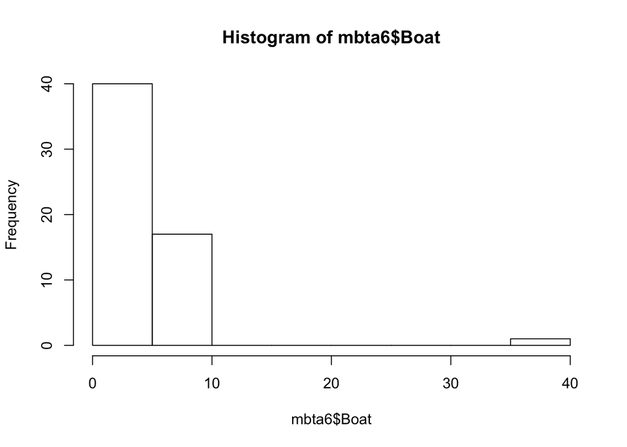

```r
# Generate a histogram of Boat ridership
hist(mbta6$Boat)
```

## Dealing with entry error

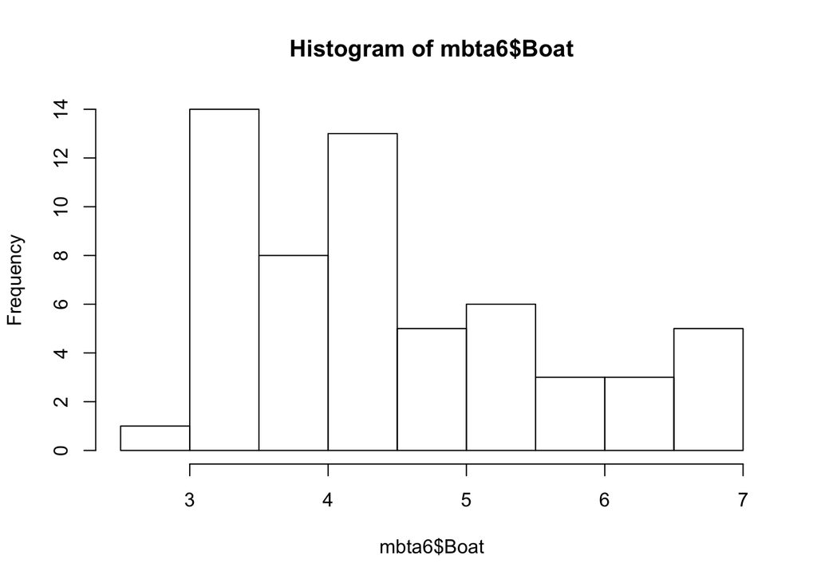

```r
# Find the row number of the incorrect value: i
i <- which(mbta6$Boat == 40)

# Replace the incorrect value with 4
mbta6$Boat[i] <- 4

# Generate a histogram of Boat column
hist(mbta6$Boat)
```